# Проект: Исследование стартапов

ФИО: Стрежнева Вера

### Введение

**Контекст:**

Финансовая компания, которая предоставляет льготные займы стартапам, хочет войти на инвестиционный рынок с прицелом на покупку, развитие и последующую перепродажу перспективных стартапов. Для разработки модели бизнеса нужна информация. Чтобы выработать общее понимание, какие данные могут быть полезны, проводится исследование на исторических данных.

Исследование на этом наборе датасетов уже пытались проводить внутренними силами. Данные неполны, поэтому заказчик просит аккуратно относиться к получаемым в процессе исследования значениям показателей и выводам и стараться оценивать их на возможные искажения.

**Цели:**

- Подготовить датасет и проверить, что данные в нём соответствуют здравому смыслу, а также ответить на вопросы заказчика как о предобработке, так и о значении данных для бизнеса.
- узнать:
  - по каким столбцам можно объединять данные из разных таблиц;
  - можно ли доверять данным о сотрудниках стартапов и их образовании;
  - что значат покупки за 0 или за 1 доллар;
  - какая цена в зависимости от категории стартапов и количества раундов финансирования перед его покупкой;
  - как рассчитать и отобразить численные показатели и динамику.
- попробовать выявить показатели и признаки, которые указывают на повышенную вероятность успешной сделки по покупке компании.

## Знакомство с данными: загрузка и первичная предобработка

Названия файлов:

- acquisition.csv
- company_and_rounds.csv
- degrees.csv
- education.csv
- fund.csv
- investment.csv
- people.csv

Они находятся в папке datasets, если вы выполняете работу на платформе. В случае, если вы делаете работу локально, доступ к файлам в папке можно получить по адресу `https://code.s3.yandex.net/datasets/` + имя файла.

### Вывод общей информации, исправление названия столбцов

- Загрузите все данные по проекту.
- Проверьте названия столбцов.
- Выведите информацию, которая необходима вам для принятия решений о предобработке, для каждого из датасетов.

```python
#импортируем нужные библиотеки
import pandas as pd
import matplotlib.pyplot as plt
import seaborn as sns
```

```python
#загружаем данные
acquisition = pd.read_csv('https://code.s3.yandex.net/datasets/acquisition.csv')
company_and_rounds = pd.read_csv('https://code.s3.yandex.net/datasets/company_and_rounds.csv')
degrees = pd.read_csv('https://code.s3.yandex.net/datasets/degrees.csv')
education = pd.read_csv('https://code.s3.yandex.net/datasets/education.csv')
fund = pd.read_csv('https://code.s3.yandex.net/datasets/fund.csv')
investment = pd.read_csv('https://code.s3.yandex.net/datasets/investment.csv')
people = pd.read_csv('https://code.s3.yandex.net/datasets/people.csv')
```

Изучим данные датасета **acquisition**:

- Содержит информацию о покупках одними компаниями других компаний
- `id` — идентификатор покупки.
- `acquiring_company_id` — идентификатор покупающей компании.
- `acquired_company_id` — идентификатор покупаемой компании.
- `term_code` — варианты расчёта.
- `price_amount` — сумма сделки.
- `acquired_at` — дата сделки.

```python
acquisition.head()
```

|  | id | acquiring_company_id | acquired_company_id | term_code | price_amount | acquired_at |
| --- | --- | --- | --- | --- | --- | --- |
| 0 | 1 | 11 | 10 | NaN | 20000000 | 2007-05-30 |
| 1 | 7 | 59 | 72 | cash | 60000000 | 2007-07-01 |
| 2 | 8 | 24 | 132 | cash | 280000000 | 2007-05-01 |
| 3 | 9 | 59 | 155 | cash | 100000000 | 2007-06-01 |
| 4 | 10 | 212 | 215 | cash | 25000000 | 2007-07-01 |

```python
acquisition.info()
```

```
<class 'pandas.core.frame.DataFrame'>
RangeIndex: 9407 entries, 0 to 9406
Data columns (total 6 columns):
 #   Column                Non-Null Count  Dtype
---  ------                --------------  -----
 0   id                    9407 non-null   int64
 1   acquiring_company_id  9407 non-null   int64
 2   acquired_company_id   9407 non-null   int64
 3   term_code             1831 non-null   object
 4   price_amount          9407 non-null   int64
 5   acquired_at           9378 non-null   object
dtypes: int64(4), object(2)
memory usage: 441.1+ KB
```

**Вывод:**

- всего 6 столбцов и 9407 строк
- есть пропуски в столбцах `term_code` и `acquired_at`
- названия столбцов верные
- содержание столбцов соответствует описанию
- можно поменять тип столбца `acquired_at` на datetime

Изучим данные датасета **company_and_rounds**:

- `company ID` — идентификатор компании.
- `name` — название компании.
- `category code` — категория области деятельности компании.
- `status` — статус компании.
- `founded at` — дата инвестирования.
- `closed at` — дата закрытия компании.
- `domain` — официальный сайт компании.
- `network username` — ник компании в сети.
- `country code` — код страны компании.
- `investment rounds` — число инвестиционных раундов.
- `funding rounds` — число раундов финансирования.
- `funding total` — сумма финансирования.
- `milestones` — вехи финансирования.
- `funding round id` — идентификатор этапа финансирования.
- `company id` — идентификатор компании.
- `funded at` — дата финансирования.
- `funding round type` — тип финансирования.
- `raised amount` — сумма финансирования.
- `pre money valuation` — предварительная денежная оценка.
- `participants` — число участников.
- `is first round` — является ли раунд первым.
- `is last round` — является раунд последним.

```python
company_and_rounds.head()
```

|  | company ID | name | category code | status | founded at | closed at | domain | network username | country code | investment rounds | ... | milestones | funding round id | company id | funded at | funding round type | raised amount | pre money valuation | participants | is first round | is last round |
| --- | --- | --- | --- | --- | --- | --- | --- | --- | --- | --- | --- | --- | --- | --- | --- | --- | --- | --- | --- | --- | --- |
| 0 | 1.0 | Wetpaint | web | operating | 2005-10-17 | NaN | wetpaint-inc.com | BachelrWetpaint | USA | 0.0 | ... | 5.0 | 888.0 | 1.0 | 2005-10-01 | series-a | 5250000.0 | 0.0 | 2.0 | 0.0 | 1.0 |
| 1 | 1.0 | Wetpaint | web | operating | 2005-10-17 | NaN | wetpaint-inc.com | BachelrWetpaint | USA | 0.0 | ... | 5.0 | 889.0 | 1.0 | 2007-01-01 | series-b | 9500000.0 | 0.0 | 3.0 | 0.0 | 0.0 |
| 2 | 1.0 | Wetpaint | web | operating | 2005-10-17 | NaN | wetpaint-inc.com | BachelrWetpaint | USA | 0.0 | ... | 5.0 | 2312.0 | 1.0 | 2008-05-19 | series-c+ | 25000000.0 | 0.0 | 4.0 | 1.0 | 0.0 |
| 3 | 10.0 | Flektor | games_video | acquired | NaN | NaN | flektor.com | NaN | USA | 0.0 | ... | 0.0 | NaN | NaN | NaN | NaN | NaN | NaN | NaN | NaN | NaN |
| 4 | 100.0 | There | games_video | acquired | NaN | NaN | there.com | NaN | USA | 0.0 | ... | 4.0 | NaN | NaN | NaN | NaN | NaN | NaN | NaN | NaN | NaN |

5 rows × 22 columns

```python
company_and_rounds.info()
```

```
<class 'pandas.core.frame.DataFrame'>
RangeIndex: 217774 entries, 0 to 217773
Data columns (total 22 columns):
 #   Column                 Non-Null Count   Dtype
---  ------                 --------------   -----
 0   company  ID            217472 non-null  float64
 1   name                   217471 non-null  object
 2   category  code         143886 non-null  object
 3   status                 217472 non-null  object
 4   founded  at            109956 non-null  object
 5   closed  at             3449 non-null    object
 6   domain                 147159 non-null  object
 7   network  username      95534 non-null   object
 8   country  code          108607 non-null  object
 9   investment  rounds     217472 non-null  float64
 10  funding  rounds        217472 non-null  float64
 11  funding  total         217472 non-null  float64
 12  milestones             217472 non-null  float64
 13  funding  round  id     52928 non-null   float64
 14  company  id            52928 non-null   float64
 15  funded  at             52680 non-null   object
 16  funding  round  type   52928 non-null   object
 17  raised  amount         52928 non-null   float64
 18  pre  money  valuation  52928 non-null   float64
 19  participants           52928 non-null   float64
 20  is  first  round       52928 non-null   float64
 21  is  last  round        52928 non-null   float64
dtypes: float64(12), object(10)
memory usage: 36.6+ MB
```

**Выводы:**

- всего 217774 строк и 22 столбца
- пропуски есть во всех столбцах
- столбцы имеют неверные названия, стоит привести их к стилю snakecase
- столбцы `company ID` и `company id` содержат данные одного характера
- тип столбцов `founded at` и `funded at` можно поменять на datetime

```python
#переименовываем столбцы
company_and_rounds = company_and_rounds.rename(columns={'company  ID': 'company_id_1',
                                  'category  code': 'category_code',
                                  'founded  at': 'founded_at',
                                  'closed  at': 'closed_at',
                                  'network  username': 'network_username',
                                  'country  code': 'country_code',
                                  'investment  rounds': 'investment_rounds',
                                    'funding  rounds': 'funding_rounds',
                                    'funding  total': 'funding_total',
                                    'milestones': 'milestones',
                                    'funding  round  id': 'funding_round_id',
                                    'company  id': 'company_id_2',
                                    'funded  at': 'funded_at',
                                    'funding  round  type': 'funding_round_type',
                                    'raised  amount': 'raised_amount',
                                    'pre  money  valuation': 'pre_money_valuation',
                                    'participants': 'participants',
                                    'is  first  round': 'is_first_round',
                                    'is  last  round': 'is_last_round'})
```

Изучим данные датасета **degrees**:

- Содержит информацию о типе образования сотрудника
- `id` — идентификатор записи.
- `object_id` — идентификатор сотрудника.
- `degree_type` — тип образования.
- `subject` — специальность.

```python
degrees.head()
```

|  | id | object_id | degree_type | subject |
| --- | --- | --- | --- | --- |
| 0 | 1 | p:6117 | MBA | NaN |
| 1 | 2 | p:6136 | BA | English, French |
| 2 | 3 | p:6136 | MS | Mass Communication |
| 3 | 4 | p:6005 | MS | Internet Technology |
| 4 | 5 | p:5832 | BCS | Computer Science, Psychology |

```python
degrees.info()
```

```
<class 'pandas.core.frame.DataFrame'>
RangeIndex: 109610 entries, 0 to 109609
Data columns (total 4 columns):
 #   Column       Non-Null Count   Dtype
---  ------       --------------   -----
 0   id           109610 non-null  int64
 1   object_id    109610 non-null  object
 2   degree_type  98389 non-null   object
 3   subject      81298 non-null   object
dtypes: int64(1), object(3)
memory usage: 3.3+ MB
```

**Вывод**:

- всего 109610 строк и 4 столбца
- названия столбцов верные
- данные соответствуют описанию
- пропуски есть в столбцах `degree_type`, `subject`
- в столбце `object_id` можем увидеть лишний префикс "p:"

Изучим данные датасета **education**:

- Содержит информацию об образовании сотрудника:
- `id` — идентификатор записи об образовании.
- `person_id` — идентификатор работника.
- `instituition` — название учебного заведения.
- `graduated_at` — дата получения образования.

```python
education.head()
```

|  | id | person_id | instituition | graduated_at |
| --- | --- | --- | --- | --- |
| 0 | 1 | 6117 | NaN | NaN |
| 1 | 2 | 6136 | Washington University, St. Louis | 1990-01-01 |
| 2 | 3 | 6136 | Boston University | 1992-01-01 |
| 3 | 4 | 6005 | University of Greenwich | 2006-01-01 |
| 4 | 5 | 5832 | Rice University | NaN |

```python
education.info()
```

```
<class 'pandas.core.frame.DataFrame'>
RangeIndex: 109610 entries, 0 to 109609
Data columns (total 4 columns):
 #   Column        Non-Null Count   Dtype
---  ------        --------------   -----
 0   id            109610 non-null  int64
 1   person_id     109610 non-null  int64
 2   instituition  109555 non-null  object
 3   graduated_at  58054 non-null   object
dtypes: int64(2), object(2)
memory usage: 3.3+ MB
```

**Выводы:**

- всего 109610 строк и 4 столбца
- столбцы названы верно
- данные соответствуют описанию
- есть пропуски в столбцах `instituition` и `graduated_at`
- тип `graduated_at` можно заменить на datetime

Изучим данные датасета **fund**:

- Содержит информацию о фондах
- `id` — идентификатор фонда.
- `name` — название фонда.
- `category_code` — категория области деятельности компании.
- `founded_at` — дата создания фонда.
- `domain` — сайт фонда.
- `network_username` — ник фонда в сети.
- `country_code` — код страны фонда.
- `investment_rounds` — число инвестиционных раундов.
- `invested_companies` — число профинансированных компаний.
- `milestones` — вехи финансирования.

```python
fund.head()
```

|  | id | name | founded_at | domain | network_username | country_code | investment_rounds | invested_companies | milestones |
| --- | --- | --- | --- | --- | --- | --- | --- | --- | --- |
| 0 | 13131 | NaN | NaN | NaN | NaN | NaN | 0 | 0 | 0 |
| 1 | 1 | Greylock Partners | 1965-01-01 | greylock.com | greylockvc | USA | 307 | 196 | 0 |
| 2 | 10 | Mission Ventures | 1996-01-01 | missionventures.com | NaN | USA | 58 | 33 | 0 |
| 3 | 100 | Kapor Enterprises, Inc. | NaN | kei.com | NaN | USA | 2 | 1 | 0 |
| 4 | 1000 | Speed Ventures | NaN | NaN | NaN | NaN | 0 | 0 | 1 |

```python
fund.info()
```

```
<class 'pandas.core.frame.DataFrame'>
RangeIndex: 11652 entries, 0 to 11651
Data columns (total 9 columns):
 #   Column              Non-Null Count  Dtype
---  ------              --------------  -----
 0   id                  11652 non-null  int64
 1   name                11649 non-null  object
 2   founded_at          4605 non-null   object
 3   domain              7362 non-null   object
 4   network_username    2149 non-null   object
 5   country_code        7053 non-null   object
 6   investment_rounds   11652 non-null  int64
 7   invested_companies  11652 non-null  int64
 8   milestones          11652 non-null  int64
dtypes: int64(4), object(5)
memory usage: 819.4+ KB
```

**Выводы:**

- всего 11652 строк и 9 столбцов
- столбцы названы верно
- данные соответствуют описанию
- пропуски есть в 5 столбцах
- тип столбца `founded_at` можно заменить на datetime

Изучим данные датасета **investment**:

- Содержит информацию о раундах инвестирования
- `id` — идентификатор этапа инвестирования.
- `funding_round_id` — идентификатор раунда инвестирования.
- `company_id` — индентификатор компании.
- `fund_id` — идентификатор фонда.

```python
investment.head()
```

|  | id | funding_round_id | company_id | fund_id |
| --- | --- | --- | --- | --- |
| 0 | 1 | 1 | 4 | 1 |
| 1 | 2 | 1 | 4 | 2 |
| 2 | 3 | 3 | 5 | 4 |
| 3 | 4 | 4 | 5 | 1 |
| 4 | 5 | 4 | 5 | 5 |

```python
investment.info()
```

```
<class 'pandas.core.frame.DataFrame'>
RangeIndex: 61403 entries, 0 to 61402
Data columns (total 4 columns):
 #   Column            Non-Null Count  Dtype
---  ------            --------------  -----
 0   id                61403 non-null  int64
 1   funding_round_id  61403 non-null  int64
 2   company_id        61403 non-null  int64
 3   fund_id           61403 non-null  int64
dtypes: int64(4)
memory usage: 1.9 MB
```

**Выводы:**

- всего 61403 строк и 4 столбца
- столбцы названы верно
- данные соответствуют описанию
- пропусков нет

Изучим данные датасета **people**:

- Содержит информацию о сотрудниках
- `id` — идентификатор сотрудника.
- `first_name` — имя сотрудника.
- `last_name` — фамилия сотрудника.
- `company_id` — идентификатор компании.
- `network_username` — ник в социальных сетях.

```python
people.head()
```

|  | id | first_name | last_name | company_id | network_username |
| --- | --- | --- | --- | --- | --- |
| 0 | 10 | Mark | Zuckerberg | 5.0 | NaN |
| 1 | 100 | Peter | Lester | 27.0 | NaN |
| 2 | 1000 | Dr. Steven | E. Saunders | 292.0 | NaN |
| 3 | 10000 | Neil | Capel | 2526.0 | NaN |
| 4 | 100000 | Sue | Pilsch | NaN | NaN |

```python
people.info()
```

```
<class 'pandas.core.frame.DataFrame'>
RangeIndex: 226709 entries, 0 to 226708
Data columns (total 5 columns):
 #   Column            Non-Null Count   Dtype
---  ------            --------------   -----
 0   id                226709 non-null  int64
 1   first_name        226700 non-null  object
 2   last_name         226705 non-null  object
 3   company_id        34615 non-null   float64
 4   network_username  38867 non-null   object
dtypes: float64(1), int64(1), object(3)
memory usage: 8.6+ MB
```

**Выводы:**

- всего 226709 строк и 5 столбцов
- столбцы названы верно
- данные соответствуют описанию
- пропуски есть в 4 столбцах

Таким образом, были изученны данные всех имеющихся датасетов, для каждого продуманы этапы предобработки по изменению названий столбцов и преобразованию типов.

### Смена типов и анализ пропусков

- Обработайте типы данных в столбцах, которые хранят значения даты и времени, если это необходимо.

```python
#приведем столбцы с датой к типу datetime
acquisition['acquired_at'] = pd.to_datetime(acquisition['acquired_at'])
company_and_rounds['founded_at'] = pd.to_datetime(company_and_rounds['founded_at'])
company_and_rounds['funded_at'] = pd.to_datetime(company_and_rounds['funded_at'])
education['graduated_at'] = pd.to_datetime(education['graduated_at'])
fund['founded_at'] = pd.to_datetime(fund['founded_at'])
```

- Оцените полноту данных — сделайте предварительный вывод, достаточно ли данных для решения задач проекта.

```python
#проверим процент пропусков в столбцах датасетов, нужных для анализа
datasets = [company_and_rounds, acquisition, people, education, degrees]
data= ['company_and_rounds', 'acquisition', 'people', 'education', 'degrees']
for i in range(5):
    print(f'Всего строк в датасете {data[i]}: {datasets[i].shape[0]}')
    print('Процент пропусков')
    print('')
    print(round((datasets[i].isna().sum()/datasets[i].shape[0]).sort_values(ascending=False)*100,2))
    print('')
```

```
Всего строк в датасете company_and_rounds: 217774
Процент пропусков

closed_at              98.42
funded_at              75.81
is_last_round          75.70
funding_round_type     75.70
is_first_round         75.70
participants           75.70
pre_money_valuation    75.70
raised_amount          75.70
funding_round_id       75.70
company_id_2           75.70
network_username       56.13
country_code           50.13
founded_at             49.51
category_code          33.93
domain                 32.43
name                    0.14
company_id_1            0.14
milestones              0.14
funding_rounds          0.14
investment_rounds       0.14
status                  0.14
funding_total           0.14
dtype: float64

Всего строк в датасете acquisition: 9407
Процент пропусков

term_code               80.54
acquired_at              0.31
id                       0.00
acquiring_company_id     0.00
acquired_company_id      0.00
price_amount             0.00
dtype: float64

Всего строк в датасете people: 226709
Процент пропусков
```

[output cut: 10 more lines]

```

graduated_at    47.04
instituition     0.05
id               0.00
person_id        0.00
dtype: float64

Всего строк в датасете degrees: 109610
Процент пропусков

subject        25.83
degree_type    10.24
id              0.00
object_id       0.00
dtype: float64
```

**Выводы:**

- один из основных датасетов **company_and_rounds** имеет довольно много пропусков в информации об инвестициях (примерно 75%), но с учетом того, что всего 217774 строк, этого должно быть достаточно для предварительных выводов. Также можно отметить 98% пропусков в столбце `closed at`, но это говорит лишь о том, что большинство компаний до сих пор осуществляют свою деятельность
- в датасете **people** около 85% строк не имеют информации об идентификаторе компании, то есть всего около 34000 строк имеют эту информацию. В целом, этого должно быть достаточно для проверки гипотез.
- пропуски (47%) в столбце `graduated_at` в датасете **education** могут говорить о том, что сотрудники либо продолжают учиться, либо имеют незаконченное образование.

Таким образом, в основных датасетах довольно большой процент пропусков, но при этом и много записей, что дает возможность провести анализ.

## Предобработка данных, предварительное исследование

### Раунды финансирования по годам

Задание необходимо выполнить без объединения и дополнительной предобработки на основе датасета `company_and_rounds.csv`.

- Составьте сводную таблицу по годам, в которой на основании столбца `raised_amount` для каждого года указан:
  - типичный размер средств, выделяемый в рамках одного раунда;
  - общее количество раундов финансирования за этот год.
- Оставьте в таблице информацию только для тех лет, для которых есть информация о более чем 50 раундах финансирования.
- На основе получившейся таблицы постройте график, который будет отражать динамику типичного размера средств, которые стартапы получали в рамках одного раунда финансирования.

На основе полученных данных ответьте на вопросы:

- В каком году типичный размер собранных в рамках одного раунда средств был максимален?
- Какая тенденция по количеству раундов и выделяемых в рамках каждого раунда средств наблюдалась в 2013 году?

Построим сводную таблицу по годам, чтобы узнать количество финансирований и типичный размер вложенных средств в рамках одного раунда

```python
#для удобства создадим новый столбец с годом финансирования, предварительно создав копию датафрейма
com_round = company_and_rounds.copy()
com_round['funded_year'] = com_round['funded_at'].dt.year
```

```python
#создаем сводную таблицу
pt = pd.pivot_table(com_round, index=com_round['funded_year'], values='raised_amount', aggfunc=['median','count'])
filtered_pt = pt[(pt[('count', 'raised_amount')] > 50)]
filtered_pt
```

| funded_year | median raised_amount | count raised_amount |
| --- | --- | --- |
| 1999.0 | 2000000.0 | 76 |
| 2000.0 | 4200000.0 | 125 |
| 2001.0 | 3000000.0 | 96 |
| 2002.0 | 4200000.0 | 116 |
| 2003.0 | 3000000.0 | 159 |
| 2004.0 | 5000000.0 | 291 |
| 2005.0 | 5500000.0 | 1633 |
| 2006.0 | 5000000.0 | 2436 |
| 2007.0 | 3973320.0 | 3279 |
| 2008.0 | 3110000.0 | 3774 |
| 2009.0 | 2000000.0 | 4151 |
| 2010.0 | 1602500.0 | 6221 |
| 2011.0 | 1200000.0 | 9204 |
| 2012.0 | 1000000.0 | 9970 |
| 2013.0 | 1200000.0 | 11072 |

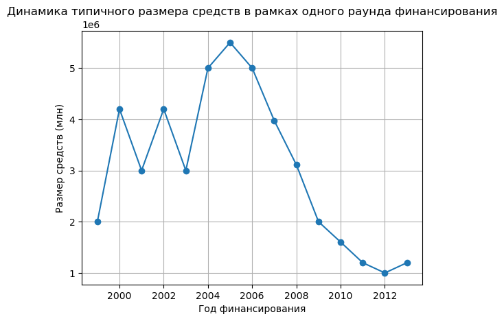

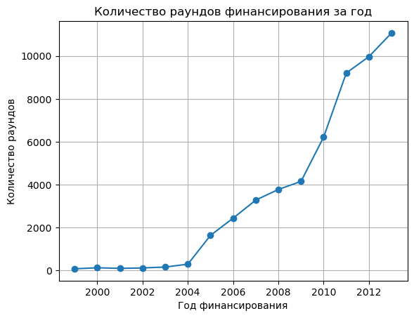

```python
#построим графики
filtered_pt.plot(kind='line', y=('median', 'raised_amount'), legend=False, marker='o', xlabel='Год финансирования', ylabel='Размер средств (млн)', title='Динамика типичного размера средств в рамках одного раунда финансирования', grid=True)
filtered_pt.plot(kind='line', y=('count', 'raised_amount'), legend=False, marker='o', xlabel='Год финансирования', ylabel='Количество раундов', title='Количество раундов финансирования за год', grid=True)
plt.show()
```

- Видим, что максимальный размер средств за один раунд финансирования был выделен в 2005 году - 5.5 млн.
- После 2005 года тенденция пошла на снижение и в 2012 достигла своего минимума в 1 млн
- При этом, начиная с 2004 года виден тренд на рост количества раундов финансирования
- В 2013 году видим максимальное количество раундов финансирования - более 10 тыс и при этом типичный размер средств на один раунд - 1.2 млн

### Люди и их образование

Заказчик хочет понять, зависит ли полнота сведений о сотрудниках (например, об их образовании) от размера компаний.

- Оцените, насколько информация об образовании сотрудников полна. Используя датасеты `people.csv` и `education.csv`, разделите все компании на несколько групп по количеству сотрудников и оцените среднюю долю сотрудников без информации об образовании в каждой из групп. Обоснуйте выбранные границы групп.
- Оцените, возможно ли для выполнения задания присоединить к этим таблицам ещё и таблицу `degrees.csv`.

Сначала разделим компании на группы по количеству сотрудников

Посмотрим на распределение количества сотрудников в компаниях:

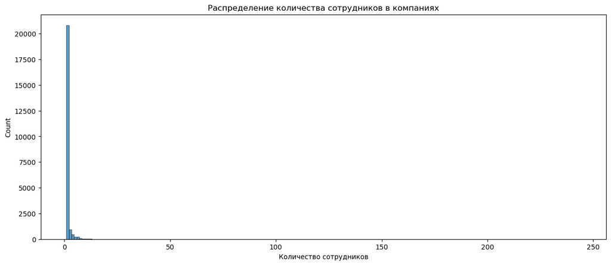

```python
# построим график распределения количества сотрудников в компаниях
company_people = people['company_id'].value_counts()

plt.figure(figsize=(15, 6))
sns.histplot(x=company_people,bins=200)

plt.title('Распределение количества сотрудников в компаниях')
plt.xlabel('Количество сотрудников')

plt.show()
```

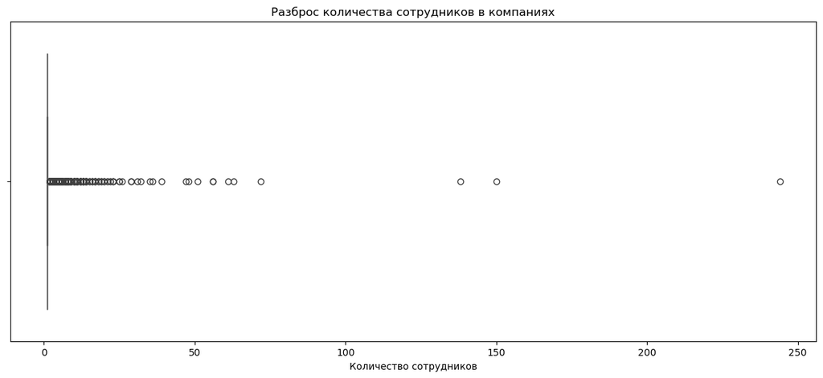

```python
plt.figure(figsize=(15, 6))
sns.boxplot(x=company_people)
plt.title('Разброс количества сотрудников в компаниях')
plt.xlabel('Количество сотрудников')
plt.show()
```

```python
company_people.describe()
```

```
count    22922.000000
mean         1.510121
std          2.764321
min          1.000000
25%          1.000000
50%          1.000000
75%          1.000000
max        244.000000
Name: count, dtype: float64
```

Исходя из полученных визуализаций, видим, что максимальное количество сотрудников - 244, а минимальное - 1. Также можно заметить, что среднее количество сотрудников 1-2, а стандартное отклонение - около 3. Это говорит о том, что компании в основном небольшие.

Разделим компании на такие группы:

- Nano: от 1 до 5 (не включит.)
- Micro: от 5 до 15 (не включит)
- Small: от 15 до 25 (не включит.)
- Average: от 25 до 50 (не включит.)
- More than average: от 50 до 100 (не включит.)
- Big: от 100

```python
def get_category(company_id):
        count = company_people.get(company_id, 0)
        if 1 <= count < 5:
            return 'Nano'
        elif 5 <= count < 15:
            return 'Micro'
        elif 15 <= count < 25:
            return 'Small'
        elif 25 <= count < 50:
            return 'Average'
        elif 50 <= count < 100:
            return 'More than average'
        elif count >= 100:
            return 'Big'
```

```python
people['company_size'] = people['company_id'].apply(get_category)
```

Далее, чтобы определить долю сотрудников, у которых есть информация об образовании, для каждой группы, надо объединить датафреймы people и education

```python
people_education = people.merge(education, left_on='id', right_on='person_id', how='left')
people_education.head()
```

|  | id_x | first_name | last_name | company_id | network_username | company_size | id_y | person_id | instituition | graduated_at |
| --- | --- | --- | --- | --- | --- | --- | --- | --- | --- | --- |
| 0 | 10 | Mark | Zuckerberg | 5.0 | NaN | More than average | 2415.0 | 10.0 | Harvard University | NaT |
| 1 | 100 | Peter | Lester | 27.0 | NaN | Micro | NaN | NaN | NaN | NaT |
| 2 | 1000 | Dr. Steven | E. Saunders | 292.0 | NaN | Nano | NaN | NaN | NaN | NaT |
| 3 | 10000 | Neil | Capel | 2526.0 | NaN | Nano | NaN | NaN | NaN | NaT |
| 4 | 100000 | Sue | Pilsch | NaN | NaN | None | NaN | NaN | NaN | NaT |

Будем считать, что информация об образовании есть, если есть год выпуска. Поэтому для удобства создадим бинарный столбец, где 1 - есть образование, 0 - нет.

```python
def grad(x):
    if x:
        return 0
    else:
        return 1
people_education['is_graduated'] = people_education['graduated_at'].isna().apply(grad)
```

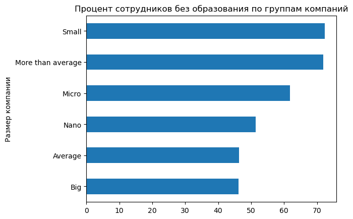

```python
#найдем процент сотрудников без образования для каждой группы
without_edu = (100-people_education.groupby('company_size')['is_graduated'].mean()*100).sort_values()
without_edu.plot(kind='barh', ylabel='Размер компании', title='Процент сотрудников без образования по группам компаний')
plt.show()
```

Изучим вопрос присоединения датафрейма degrees

```python
degrees.head()
```

|  | id | object_id | degree_type | subject |
| --- | --- | --- | --- | --- |
| 0 | 1 | p:6117 | MBA | NaN |
| 1 | 2 | p:6136 | BA | English, French |
| 2 | 3 | p:6136 | MS | Mass Communication |
| 3 | 4 | p:6005 | MS | Internet Technology |
| 4 | 5 | p:5832 | BCS | Computer Science, Psychology |

Видно, что его можно присоединить к датафрейму people_education, но если убрать префикс 'p:' в начале `object_id`

```python
degrees['object_id'] = degrees['object_id'].str.replace('p:','',regex=True)
degrees.head()
```

|  | id | object_id | degree_type | subject |
| --- | --- | --- | --- | --- |
| 0 | 1 | 6117 | MBA | NaN |
| 1 | 2 | 6136 | BA | English, French |
| 2 | 3 | 6136 | MS | Mass Communication |
| 3 | 4 | 6005 | MS | Internet Technology |
| 4 | 5 | 5832 | BCS | Computer Science, Psychology |

### Объединять или не объединять — вот в чём вопрос

Некоторые названия столбцов встречаются в датасетах чаще других. И, например, в результате предварительной проверки датасетов было выяснено, что столбец `company_id` подходит для объединения данных, так как большая часть значений встречается в разных датасетах не один, а несколько раз. Этот столбец может быть использован для объединения данных.

- Установите, подходит ли для объединения данных столбец `network_username`, который встречается в нескольких датасетах. Нам необходимо понимать, дублируется ли для разных датасетов информация в столбцах с таким названием, и если да — то насколько часто.
- Оцените, можно ли использовать столбцы с именем `network_username` для объединения данных.

Столбец `network_username` встречается в датасетах **people, company_and_rounds, fund**.

Нас интересует, совпадают ли эти значения для датасетов **company_and_rounds, fund** и можно ли его использовать для присоединения.

```python
#проверим, сколько общих элементов по этому столбцу присутствуют в датасетах
#смотрим все уникальные элементы
unique_username_company = set(company_and_rounds['network_username'].unique())
unique_username_fund = set(fund['network_username'].unique())

#ищем пересечение уникальных
inter = unique_username_company.intersection(unique_username_fund)

#ищем общее количество возможных значений
un = unique_username_company.union(unique_username_fund)
print('Общее количество уникальных значений network_username: ', len(un))
print('Количество одинаковых значений network_username для company_and_rounds и fund: ', len(inter))
print(f'Это составляет {round(len(inter)/len(un)*100,2)}% от общего количества уникальных значений')
```

```
Общее количество уникальных значений network_username:  81600
Количество одинаковых значений network_username для company_and_rounds и fund:  71
Это составляет 0.09% от общего количества уникальных значений
```

Таким образом, в датасетах **company_and_rounds** и **fund** почти нет сопадений по столбцу `network_username`, поэтому объединение по этому столбцу будет некорректным.

### Проблемный датасет и причина возникновения пропусков

Во время собственного анализа данных у заказчика больше всего вопросов возникло к датасету `company_and_rounds.csv`. В нём много пропусков как раз в информации о раундах, которая заказчику важна. Хотя информация об общем объёме финансирования по раундам присутствует в других датасетах, заказчик считает данные `company_and_rounds.csv` о размере средств наиболее верными.

- Любым удобным способом приведите данные в вид, который позволяет проводить анализ в разрезе отдельных компаний. Можно изменять форму данных, порядок их хранения. Обратите внимание на структуру датасета, порядок и названия столбцов, проанализируйте значения.

По гипотезе заказчика данные по компаниям из этой таблицы раньше хранились иначе, более удобным для исследования образом.

- Максимальным образом сохраняя данные, сохранив их связность и исключив возможные возникающие при этом ошибки, подготовьте данные так, чтобы удобно было отобрать компании по параметрам и рассчитать показатели из расчёта на одну компанию.

Определим стратегию, по которой будем разделять датафрейм

```python
company_and_rounds.head()
```

|  | company_id_1 | name | category_code | status | founded_at | closed_at | domain | network_username | country_code | investment_rounds | ... | milestones | funding_round_id | company_id_2 | funded_at | funding_round_type | raised_amount | pre_money_valuation | participants | is_first_round | is_last_round |
| --- | --- | --- | --- | --- | --- | --- | --- | --- | --- | --- | --- | --- | --- | --- | --- | --- | --- | --- | --- | --- | --- |
| 0 | 1.0 | Wetpaint | web | operating | 2005-10-17 | NaN | wetpaint-inc.com | BachelrWetpaint | USA | 0.0 | ... | 5.0 | 888.0 | 1.0 | 2005-10-01 | series-a | 5250000.0 | 0.0 | 2.0 | 0.0 | 1.0 |
| 1 | 1.0 | Wetpaint | web | operating | 2005-10-17 | NaN | wetpaint-inc.com | BachelrWetpaint | USA | 0.0 | ... | 5.0 | 889.0 | 1.0 | 2007-01-01 | series-b | 9500000.0 | 0.0 | 3.0 | 0.0 | 0.0 |
| 2 | 1.0 | Wetpaint | web | operating | 2005-10-17 | NaN | wetpaint-inc.com | BachelrWetpaint | USA | 0.0 | ... | 5.0 | 2312.0 | 1.0 | 2008-05-19 | series-c+ | 25000000.0 | 0.0 | 4.0 | 1.0 | 0.0 |
| 3 | 10.0 | Flektor | games_video | acquired | NaT | NaN | flektor.com | NaN | USA | 0.0 | ... | 0.0 | NaN | NaN | NaT | NaN | NaN | NaN | NaN | NaN | NaN |
| 4 | 100.0 | There | games_video | acquired | NaT | NaN | there.com | NaN | USA | 0.0 | ... | 4.0 | NaN | NaN | NaT | NaN | NaN | NaN | NaN | NaN | NaN |

5 rows × 22 columns

```python
company_and_rounds.info()
```

```
<class 'pandas.core.frame.DataFrame'>
RangeIndex: 217774 entries, 0 to 217773
Data columns (total 22 columns):
 #   Column               Non-Null Count   Dtype
---  ------               --------------   -----
 0   company_id_1         217472 non-null  float64
 1   name                 217471 non-null  object
 2   category_code        143886 non-null  object
 3   status               217472 non-null  object
 4   founded_at           109956 non-null  datetime64[ns]
 5   closed_at            3449 non-null    object
 6   domain               147159 non-null  object
 7   network_username     95534 non-null   object
 8   country_code         108607 non-null  object
 9   investment_rounds    217472 non-null  float64
 10  funding_rounds       217472 non-null  float64
 11  funding_total        217472 non-null  float64
 12  milestones           217472 non-null  float64
 13  funding_round_id     52928 non-null   float64
 14  company_id_2         52928 non-null   float64
 15  funded_at            52680 non-null   datetime64[ns]
 16  funding_round_type   52928 non-null   object
 17  raised_amount        52928 non-null   float64
 18  pre_money_valuation  52928 non-null   float64
 19  participants         52928 non-null   float64
 20  is_first_round       52928 non-null   float64
 21  is_last_round        52928 non-null   float64
dtypes: datetime64[ns](2), float64(12), object(8)
memory usage: 36.6+ MB
```

По содержанию столбцов, их названиям и описанию датафрейма, можно заметить, что часть столбцов относится четко к компаниям, а часть столбцов к раундам финансирования. Разделение четко видно и по количеству пропусков: можно предположить, что все данные, начиная со столбца `funding_round_id` будут относится к другому датасету.

В соответствии с этим разделим датафрейм на два таким образом:

1. **company**:
   - company_id_1
   - name
   - category_code
   - status
   - founded_at
   - closed_at
   - domain
   - network_username
   - country_code
   - investment_rounds
   - funding_rounds
   - funding_total
   - milestones
2. **rounds**:
   - funding_round_id
   - company_id_2
   - funded_at
   - funding_round_type
   - raised_amount
   - pre_money_valuation
   - participants
   - is_first_round
   - is_last_round

```python
company = company_and_rounds[['company_id_1',
                                'name',
                                'category_code',
                                'status',
                                'founded_at',
                                'closed_at',
                                'domain',
                                'network_username',
                                'country_code',
                                'investment_rounds',
                                'funding_rounds',
                                'funding_total',
                                'milestones']].copy()

rounds = company_and_rounds[['funding_round_id',
                                'company_id_2',
                                'funded_at',
                                'funding_round_type',
                                'raised_amount',
                                'pre_money_valuation',
                                'participants',
                                'is_first_round',
                                'is_last_round']].copy()
```

```python
print(company.info())
company.head()
```

```
<class 'pandas.core.frame.DataFrame'>
RangeIndex: 217774 entries, 0 to 217773
Data columns (total 13 columns):
 #   Column             Non-Null Count   Dtype
---  ------             --------------   -----
 0   company_id_1       217472 non-null  float64
 1   name               217471 non-null  object
 2   category_code      143886 non-null  object
 3   status             217472 non-null  object
 4   founded_at         109956 non-null  datetime64[ns]
 5   closed_at          3449 non-null    object
 6   domain             147159 non-null  object
 7   network_username   95534 non-null   object
 8   country_code       108607 non-null  object
 9   investment_rounds  217472 non-null  float64
 10  funding_rounds     217472 non-null  float64
 11  funding_total      217472 non-null  float64
 12  milestones         217472 non-null  float64
dtypes: datetime64[ns](1), float64(5), object(7)
memory usage: 21.6+ MB
None
```

|  | company_id_1 | name | category_code | status | founded_at | closed_at | domain | network_username | country_code | investment_rounds | funding_rounds | funding_total | milestones |
| --- | --- | --- | --- | --- | --- | --- | --- | --- | --- | --- | --- | --- | --- |
| 0 | 1.0 | Wetpaint | web | operating | 2005-10-17 | NaN | wetpaint-inc.com | BachelrWetpaint | USA | 0.0 | 3.0 | 39750000.0 | 5.0 |
| 1 | 1.0 | Wetpaint | web | operating | 2005-10-17 | NaN | wetpaint-inc.com | BachelrWetpaint | USA | 0.0 | 3.0 | 39750000.0 | 5.0 |
| 2 | 1.0 | Wetpaint | web | operating | 2005-10-17 | NaN | wetpaint-inc.com | BachelrWetpaint | USA | 0.0 | 3.0 | 39750000.0 | 5.0 |
| 3 | 10.0 | Flektor | games_video | acquired | NaT | NaN | flektor.com | NaN | USA | 0.0 | 0.0 | 0.0 | 0.0 |
| 4 | 100.0 | There | games_video | acquired | NaT | NaN | there.com | NaN | USA | 0.0 | 0.0 | 0.0 | 4.0 |

```python
print(rounds.info())
rounds.head()
```

```
<class 'pandas.core.frame.DataFrame'>
RangeIndex: 217774 entries, 0 to 217773
Data columns (total 9 columns):
 #   Column               Non-Null Count  Dtype
---  ------               --------------  -----
 0   funding_round_id     52928 non-null  float64
 1   company_id_2         52928 non-null  float64
 2   funded_at            52680 non-null  datetime64[ns]
 3   funding_round_type   52928 non-null  object
 4   raised_amount        52928 non-null  float64
 5   pre_money_valuation  52928 non-null  float64
 6   participants         52928 non-null  float64
 7   is_first_round       52928 non-null  float64
 8   is_last_round        52928 non-null  float64
dtypes: datetime64[ns](1), float64(7), object(1)
memory usage: 15.0+ MB
None
```

|  | funding_round_id | company_id_2 | funded_at | funding_round_type | raised_amount | pre_money_valuation | participants | is_first_round | is_last_round |
| --- | --- | --- | --- | --- | --- | --- | --- | --- | --- |
| 0 | 888.0 | 1.0 | 2005-10-01 | series-a | 5250000.0 | 0.0 | 2.0 | 0.0 | 1.0 |
| 1 | 889.0 | 1.0 | 2007-01-01 | series-b | 9500000.0 | 0.0 | 3.0 | 0.0 | 0.0 |
| 2 | 2312.0 | 1.0 | 2008-05-19 | series-c+ | 25000000.0 | 0.0 | 4.0 | 1.0 | 0.0 |
| 3 | NaN | NaN | NaT | NaN | NaN | NaN | NaN | NaN | NaN |
| 4 | NaN | NaN | NaT | NaN | NaN | NaN | NaN | NaN | NaN |

Таким образом, мы получили два датасета:

1. **company**, в котором 13 столбцов
2. **rounds**, в котором 9 столбцов

Теперь выполним предобработку для дальнейшей работы

```python
#проверим дубликаты
print('Количество явных дубликатов в датасете company: ',company.duplicated().sum())
print('Количество явных дубликатов в датасете rounds: ',rounds.duplicated().sum())
```

```
Количество явных дубликатов в датасете company:  21220
Количество явных дубликатов в датасете rounds:  164845
```

```python
#удаляем явные дубликаты
company = company.drop_duplicates()
rounds = rounds.drop_duplicates()
```

```python
#проверим на неявные дубликаты в датафрейме company по столбцу name
company['name'].duplicated().sum()
```

```
48
```

```python
#удаляем неявные дубликаты
company = company.drop_duplicates('name')
```

```python
company.info()
print(rounds.info())
```

```
<class 'pandas.core.frame.DataFrame'>
Index: 196506 entries, 0 to 217469
Data columns (total 13 columns):
 #   Column             Non-Null Count   Dtype
---  ------             --------------   -----
 0   company_id_1       196506 non-null  float64
 1   name               196505 non-null  object
 2   category_code      123175 non-null  object
 3   status             196506 non-null  object
 4   founded_at         91220 non-null   datetime64[ns]
 5   closed_at          2620 non-null    object
 6   domain             126532 non-null  object
 7   network_username   80586 non-null   object
 8   country_code       87985 non-null   object
 9   investment_rounds  196506 non-null  float64
 10  funding_rounds     196506 non-null  float64
 11  funding_total      196506 non-null  float64
 12  milestones         196506 non-null  float64
dtypes: datetime64[ns](1), float64(5), object(7)
memory usage: 21.0+ MB
<class 'pandas.core.frame.DataFrame'>
Index: 52929 entries, 0 to 217773
Data columns (total 9 columns):
 #   Column               Non-Null Count  Dtype
---  ------               --------------  -----
 0   funding_round_id     52928 non-null  float64
 1   company_id_2         52928 non-null  float64
 2   funded_at            52680 non-null  datetime64[ns]
 3   funding_round_type   52928 non-null  object
 4   raised_amount        52928 non-null  float64
 5   pre_money_valuation  52928 non-null  float64
 6   participants         52928 non-null  float64
 7   is_first_round       52928 non-null  float64
 8   is_last_round        52928 non-null  float64
dtypes: datetime64[ns](1), float64(7), object(1)
memory usage: 4.0+ MB
None
```

Изучим пропуски:

```python
#пропуски в процентах
print((company.isna().sum()/company.shape[0]*100).sort_values())
(rounds.isna().sum()/rounds.shape[0]*100).sort_values()
```

```
company_id_1          0.000000
status                0.000000
investment_rounds     0.000000
funding_rounds        0.000000
funding_total         0.000000
milestones            0.000000
name                  0.000509
domain               35.609091
category_code        37.317436
founded_at           53.579026
country_code         55.225286
network_username     58.990565
closed_at            98.666707
dtype: float64
```

```
funding_round_id       0.001889
company_id_2           0.001889
funding_round_type     0.001889
raised_amount          0.001889
pre_money_valuation    0.001889
participants           0.001889
is_first_round         0.001889
is_last_round          0.001889
funded_at              0.470442
dtype: float64
```

Удалим пропуски в столбцах, где их доля меньше процента

```python
company = company.dropna(subset=['company_id_1',
                                 'status',
                                 'investment_rounds',
                                 'funding_rounds',
                                 'funding_total',
                                 'milestones',
                                 'name'])

rounds = rounds.dropna(subset=['funding_round_id',
                                'company_id_2',
                                'funded_at',
                                'funding_round_type',
                                'raised_amount',
                                'pre_money_valuation',
                                'participants',
                                'is_first_round',
                                'is_last_round'])
```

Теперь поменяем типы столбцов с id на int

```python
company['company_id_1'] = pd.to_numeric(company['company_id_1'], downcast='integer')
rounds['funding_round_id'] = pd.to_numeric(rounds['funding_round_id'], downcast='integer')
rounds['company_id_2'] = pd.to_numeric(rounds['company_id_2'], downcast='integer')
```

```python
#отсортируем датафреймы по id
company = company.sort_values(by='company_id_1')
rounds = rounds.sort_values(by='funding_round_id')
```

```python
#сбросим индексы у этих датафреймов
company = company.reset_index(drop=True)
rounds = rounds.reset_index(drop=True)
```

```python
company.info()
print(rounds.info())
```

```
<class 'pandas.core.frame.DataFrame'>
RangeIndex: 196505 entries, 0 to 196504
Data columns (total 13 columns):
 #   Column             Non-Null Count   Dtype
---  ------             --------------   -----
 0   company_id_1       196505 non-null  int32
 1   name               196505 non-null  object
 2   category_code      123175 non-null  object
 3   status             196505 non-null  object
 4   founded_at         91219 non-null   datetime64[ns]
 5   closed_at          2619 non-null    object
 6   domain             126532 non-null  object
 7   network_username   80586 non-null   object
 8   country_code       87985 non-null   object
 9   investment_rounds  196505 non-null  float64
 10  funding_rounds     196505 non-null  float64
 11  funding_total      196505 non-null  float64
 12  milestones         196505 non-null  float64
dtypes: datetime64[ns](1), float64(4), int32(1), object(7)
memory usage: 18.7+ MB
<class 'pandas.core.frame.DataFrame'>
RangeIndex: 52680 entries, 0 to 52679
Data columns (total 9 columns):
 #   Column               Non-Null Count  Dtype
---  ------               --------------  -----
 0   funding_round_id     52680 non-null  int32
 1   company_id_2         52680 non-null  int32
 2   funded_at            52680 non-null  datetime64[ns]
 3   funding_round_type   52680 non-null  object
 4   raised_amount        52680 non-null  float64
 5   pre_money_valuation  52680 non-null  float64
 6   participants         52680 non-null  float64
 7   is_first_round       52680 non-null  float64
 8   is_last_round        52680 non-null  float64
dtypes: datetime64[ns](1), float64(5), int32(2), object(1)
memory usage: 3.2+ MB
None
```

Итоги:

- в ходе предобработки были удалены явные дубликаты в обоих датасетах
- в датасете company были удалены неявные дубликаты по столбцу name
- удалены пропуски в столбцах, где их процент был меньше 1%
- типы столбцов с id изменены с float на int
- датасеты отсортированы по company_id_1 и funding_round_id
- сброшены индексы
- теперь в датасете company 196505 строк и 13 столбцов
- в датасете rounds 52680 строк и 9 столбцов

## Исследовательский анализ объединённых таблиц

Приступите к шагу 3 после проверки ревьюера.

### Объединение данных

Объедините данные для ответа на вопросы заказчика, которые касаются интересующих его компаний.

В качестве основы для объединённой таблицы возьмите данные из обработанного датасета `company_and_rounds.csv` — выберите только те компании, у которых указаны значения `funding_rounds` или `investment_rounds` больше нуля, и те, у которых в колонке `status` указано `acquired`.

Далее работайте только с этими данными.

```python
#выделим нужные строки из датафрейма company
new_companies = company[((company['funding_rounds']>0) | (company['investment_rounds']>0)) | (company['status']=='acquired')].copy()
```

```python
new_companies.shape[0]
```

```
40745
```

### Анализ выбросов

Заказчика интересует обычный для рассматриваемого периода размер средств, который предоставлялся компаниям.

- По предобработанному столбцу `funding_total` графическим способом оцените, какой размер общего финансирования для одной компании будет типичным, а какой — выбивающимся.
- В процессе расчёта значений обратите внимание, например, на показатели, возвращаемые методом `.describe()`, — объясните их. Применимы ли к таким данным обычные способы нахождения типичных значений?

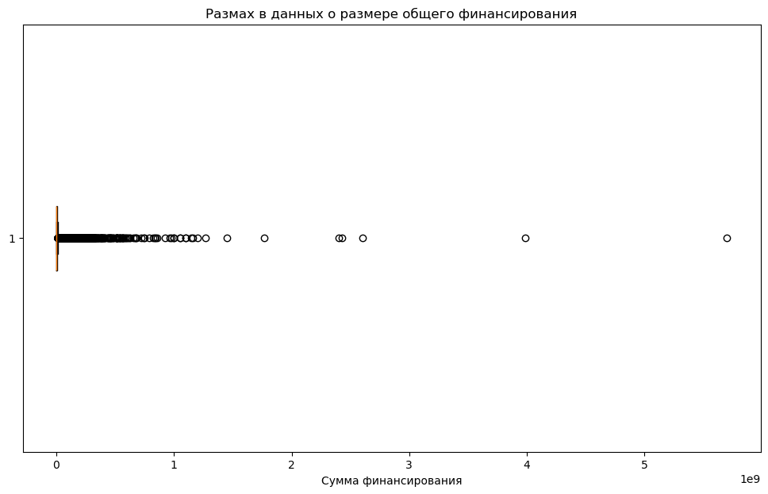

```python
#построим ящик с усами, чтобы найти выбросы и посмотреть на размах
plt.figure(figsize=(12, 7))
plt.boxplot(new_companies['funding_total'], vert=False)
plt.title('Размах в данных о размере общего финансирования')
plt.xlabel('Сумма финансирования')
plt.show()
```

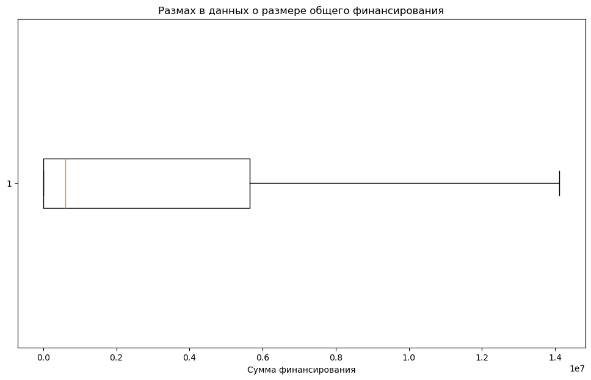

```python
#построим ящик с усами без выбросов
plt.figure(figsize=(12, 7))
plt.boxplot(new_companies['funding_total'], vert=False, showfliers=False)
plt.title('Размах в данных о размере общего финансирования')
plt.xlabel('Сумма финансирования')
plt.show()
```

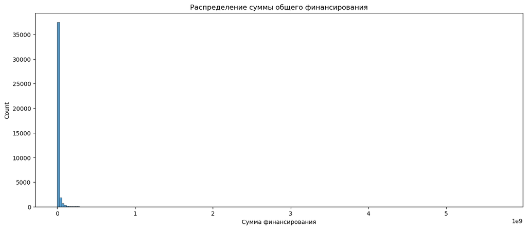

```python
#построим общее распределение
plt.figure(figsize=(15, 6))
sns.histplot(x=new_companies['funding_total'], bins=200)
plt.title('Распределение суммы общего финансирования')
plt.xlabel('Сумма финансирования')

plt.show()
```

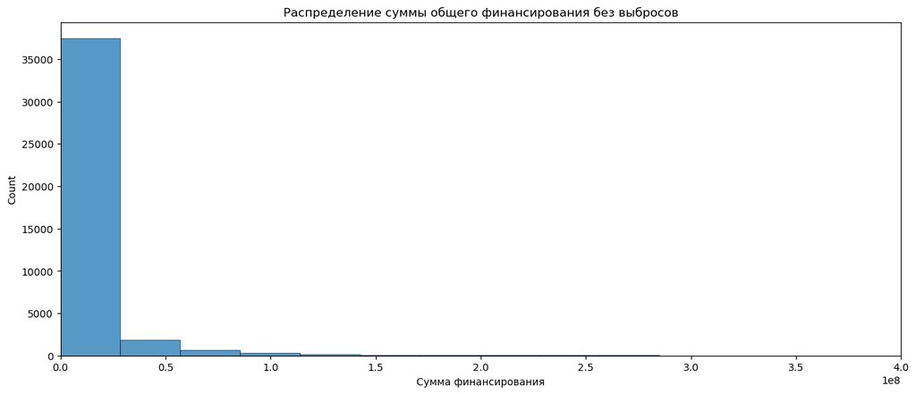

```python
#построим распределение без выбросов
plt.figure(figsize=(15, 6))
sns.histplot(x=new_companies['funding_total'], bins=200)
plt.xlim(0, 0.4e9)
plt.title('Распределение суммы общего финансирования без выбросов')
plt.xlabel('Сумма финансирования')

plt.show()
```

Без учета данного выброса, типичным значением суммы финансирования является сумма около 1 млн. Значения при этом в основном варьируются от 0 до 6 млн.

Изучим данные с помощью describe

```python
new_companies['funding_total'].describe()
```

```
count    4.074500e+04
mean     1.013563e+07
std      5.646570e+07
min      0.000000e+00
25%      0.000000e+00
50%      6.000000e+05
75%      5.650000e+06
max      5.700000e+09
Name: funding_total, dtype: float64
```

Можно сказать, что данные, получаемые этим методом (и графиками без учета выбросов), могут быть некорректными в силу присутствия в них выбросов, искажать настоящие значения.

### Куплены забесплатно?

- Исследуйте компании, которые были проданы за ноль или за один доллар, и при этом известно, что у них был ненулевой общий объём финансирования.
- Рассчитайте аналитически верхнюю и нижнюю границу выбросов для столбца `funding_total` и укажите, каким процентилям границы соответствуют. Учитывая озвученные выше предпосылки и собственные соображения, сделайте выводы о корректности планируемой заказчиком замены нижней и верхней границы выбросов на значения, рассчитанные по процентилям.

Для первого задания присоединим к таблице датафрейм **acquisition**

```python
com_acq = new_companies.merge(acquisition, left_on='company_id_1', right_on='acquired_company_id', how='left')
```

Отфильтруем нужные значения

```python
com_acq_new = com_acq[((com_acq['price_amount']==0) | (com_acq['price_amount']==1)) & (com_acq['funding_total']>0)].copy()
```

Для рассчета границ выбросов будем пользоваться межквартильным размахом IQR

```python
#!pip install skipy
```

```python
from scipy.stats import percentileofscore
#вычисляем q1 и q3
q_25 = com_acq_new['funding_total'].quantile(0.25)
q_75 = com_acq_new['funding_total'].quantile(0.75)

iqr = q_75-q_25

#вычисляем нижнюю и верхнюю границу
up = q_75+1.5*iqr
down = q_25-1.5*iqr

#с помощью scipy.stats определяем, каким процентилям соответстсвуют значения
print('Нижняя граница выбросов: ', down, f", что соответствует процентилю {percentileofscore(com_acq_new['funding_total'], down)}")
print('Верхняя граница выбросов: ', up, f", что соответствует процентилю {percentileofscore(com_acq_new['funding_total'], up)}")
```

```
Нижняя граница выбросов:  -18250000.0 , что соответствует процентилю 0.0
Верхняя граница выбросов:  35750000.0 , что соответствует процентилю 90.91470951792337
```

**Выводы**:

- получили нижнюю границу выбросов соответствующую 0 процентилю, значит выбросов в нижней части нет.
- верхняя граница выбросов соответствует примерно 91 процентилю, что означает 9% выбросов сверху.
- значения, в целом, корректны и могут быть использованы.

### Цены стартапов по категориям

Категории стартапов с наибольшими ценами и значительным разбросом цен могут быть наиболее привлекательными для крупных инвесторов, которые готовы к высоким рискам ради потенциально больших доходов. Среди категорий стартапов выделите категории стартапов, характеризующиеся:

- наибольшими ценами;
- и наибольшим разбросом цен за стартап.

Объясните, почему решили составить топ именно из такого числа категорий и почему рассчитывали именно так.

```python
com_acq
```

|  | company_id_1 | name | category_code | status | founded_at | closed_at | domain | network_username | country_code | investment_rounds | funding_rounds | funding_total | milestones | id | acquiring_company_id | acquired_company_id | term_code | price_amount | acquired_at |
| --- | --- | --- | --- | --- | --- | --- | --- | --- | --- | --- | --- | --- | --- | --- | --- | --- | --- | --- | --- |
| 0 | 1 | Wetpaint | web | operating | 2005-10-17 | NaN | wetpaint-inc.com | BachelrWetpaint | USA | 0.0 | 3.0 | 3.975000e+07 | 5.0 | NaN | NaN | NaN | NaN | NaN | NaT |
| 1 | 4 | Digg | news | acquired | 2004-10-11 | NaN | digg.com | digg | USA | 0.0 | 4.0 | 4.500000e+07 | 8.0 | 7386.0 | 20953.0 | 4.0 | NaN | 500000.0 | 2012-07-12 |
| 2 | 5 | Socialnet | social | ipo | 2004-02-01 | NaN | socialnet.com | socialnet | USA | 3.0 | 11.0 | 2.425700e+09 | 5.0 | NaN | NaN | NaN | NaN | NaN | NaT |
| 3 | 7 | Omnidrive | network_hosting | closed | 2005-11-01 | 2008-09-15 | omnidrive.com | Nomadesk | ISR | 0.0 | 1.0 | 8.000000e+05 | 4.0 | NaN | NaN | NaN | NaN | NaN | NaT |
| 4 | 8 | Postini | web | acquired | 1999-06-02 | NaN | postini.com | NaN | USA | 0.0 | 0.0 | 0.000000e+00 | 0.0 | 419.0 | 59.0 | 8.0 | cash | 625000000.0 | 2007-07-09 |
| ... | ... | ... | ... | ... | ... | ... | ... | ... | ... | ... | ... | ... | ... | ... | ... | ... | ... | ... | ... |
| 40883 | 286183 | Wedding Spot | web | operating | 2013-05-01 | NaN | wedding-spot.com | weddingspot | USA | 0.0 | 1.0 | 2.250000e+05 | 0.0 | NaN | NaN | NaN | NaN | NaN | NaT |
| 40884 | 286184 | Seldar Pharma | biotech | operating | NaT | NaN | NaN | NaN | USA | 0.0 | 1.0 | 1.299900e+07 | 0.0 | NaN | NaN | NaN | NaN | NaN | NaT |
| 40885 | 286186 | Micromidas | cleantech | operating | NaT | NaN | micromidas.com | NaN | USA | 0.0 | 1.0 | 2.156060e+06 | 0.0 | NaN | NaN | NaN | NaN | NaN | NaT |
| 40886 | 286200 | STWA | other | operating | 1998-01-01 | NaN | stwa.com | NaN | USA | 0.0 | 1.0 | 1.588120e+06 | 0.0 | NaN | NaN | NaN | NaN | NaN | NaT |
| 40887 | 286215 | The Betty Mills Company | ecommerce | operating | NaT | NaN | bettymills.com | NaN | USA | 0.0 | 1.0 | 2.712500e+05 | 0.0 | NaN | NaN | NaN | NaN | NaN | NaT |

40888 rows × 19 columns

Сгруппируем датасет по категориям стартапов и найдем для них среднее отклонение и медиану

```python
# создадим сводную таблицу с нужными характеристиками
pv = com_acq.pivot_table(index='category_code', values='price_amount', aggfunc=['median', 'std'])
pv
```

| category_code | median price_amount | std price_amount |
| --- | --- | --- |
| advertising | 0.0 | 2.799226e+08 |
| analytics | 0.0 | 5.267164e+07 |
| automotive | 43000000.0 | 2.297758e+09 |
| biotech | 13200000.0 | 1.540374e+09 |
| cleantech | 0.0 | 5.522873e+08 |
| consulting | 0.0 | 5.054814e+08 |
| design | 0.0 | 0.000000e+00 |
| ecommerce | 0.0 | 1.512364e+08 |
| education | 0.0 | 1.253642e+08 |
| enterprise | 0.0 | 1.280882e+11 |
| fashion | 0.0 | 9.574291e+07 |
| finance | 600000.0 | 7.960985e+08 |
| games_video | 0.0 | 7.623746e+08 |
| hardware | 0.0 | 4.239758e+08 |
| health | 0.0 | 1.249084e+09 |
| hospitality | 12500000.0 | 6.514494e+08 |
| legal | 0.0 | 0.000000e+00 |
| local | 0.0 | 9.318549e+06 |
| manufacturing | 72000000.0 | 9.696580e+08 |
| medical | 0.0 | 1.059509e+08 |
| messaging | 0.0 | 4.241277e+07 |
| mobile | 0.0 | 7.137738e+08 |
| music | 0.0 | 7.219858e+07 |
| nanotech | 584000000.0 | NaN |
| network_hosting | 0.0 | 4.184677e+08 |
| news | 0.0 | 7.096563e+07 |
| nonprofit | 0.0 | NaN |
| other | 0.0 | 1.085129e+09 |
| photo_video | 0.0 | 2.877321e+08 |
| public_relations | 0.0 | 4.059244e+09 |
| real_estate | 50000000.0 | 2.505123e+09 |
| search | 0.0 | 1.941578e+08 |
| security | 0.0 | 7.645662e+08 |
| semiconductor | 0.0 | 7.904889e+08 |
| social | 0.0 | 3.185975e+07 |
| software | 0.0 | 6.568300e+08 |
| sports | 0.0 | 4.265618e+08 |
| transportation | 0.0 | 4.088486e+08 |
| travel | 0.0 | 5.044630e+07 |
| web | 0.0 | 3.761718e+08 |

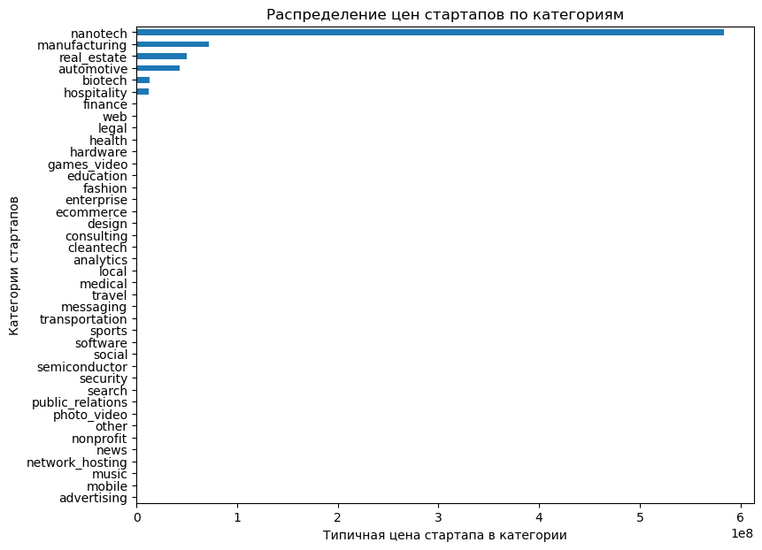

```python
#построим столбчатый график распределения типичных цен
pv.sort_values(by=('median', 'price_amount')).plot(kind='barh', y = ('median', 'price_amount'),
                                                   legend=False, figsize=(9,7),
                                                   ylabel='Категории стартапов',
                                                   xlabel='Типичная цена стартапа в категории',
                                                   title='Распределение цен стартапов по категориям')
plt.show()
```

1. nanotech
2. manufacturing
3. real_estate
4. automotive
5. biotech
6. hospitality

```python
#заполним два пустых значения 0, чтобы график был нагляднее
pv = pv.fillna(0)
```

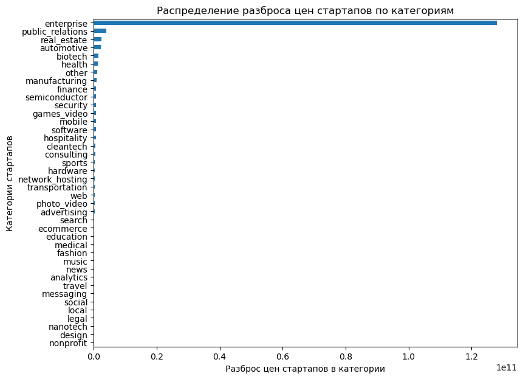

```python
#построим график распределения разбросов цен
pv.sort_values(by=('std', 'price_amount')).plot(kind='barh', y = ('std', 'price_amount'),
                                                   legend=False, figsize=(9,7),
                                                   ylabel='Категории стартапов',
                                                   xlabel='Разброс цен стартапов в категории',
                                                   title='Распределение разброса цен стартапов по категориям')
plt.show()
```

Можно отметить, что разброс в категории enterprise сильно отличается от разброса в остальных категориях. Это может быть связано с аномальными значениями или ошибками в данных. Проверим это

```python
com_acq['price_amount'].describe()
```

```
count    9.390000e+03
mean     3.939881e+08
std      2.684624e+10
min      0.000000e+00
25%      0.000000e+00
50%      0.000000e+00
75%      2.362550e+04
max      2.600000e+12
Name: price_amount, dtype: float64
```

Видим, что максимальное значение сильно отличается от перцентилей и может искажать среднее значение и стандартное отклонение. Скорее всего, это может быть ошибкой в данных. Значение в 2,6 трлн может на самом деле быть 26 млрд. Можно попробовать исправить значение и посмотреть на распределение снова.

```python
#найдем компанию с аномальным значением
com_acq[['price_amount','company_id_1']].sort_values(by='price_amount',ascending=False).head()
```

|  | price_amount | company_id_1 |
| --- | --- | --- |
| 1409 | 2.600000e+12 | 2467 |
| 2055 | 3.900000e+10 | 4498 |
| 2129 | 3.500000e+10 | 4819 |
| 9846 | 2.810000e+10 | 32380 |
| 33413 | 2.600000e+10 | 220208 |

```python
#меняем цену
com_acq_2 = com_acq.copy()
com_acq_2.loc[com_acq['company_id_1']==2467,'price_amount']=26*10**9
```

```python
#строим вторую сводную таблицу с правками
pv_2 = com_acq_2.pivot_table(index='category_code', values='price_amount', aggfunc=['median', 'std'], fill_value=0)
pv_2=pv_2.fillna(0)
```

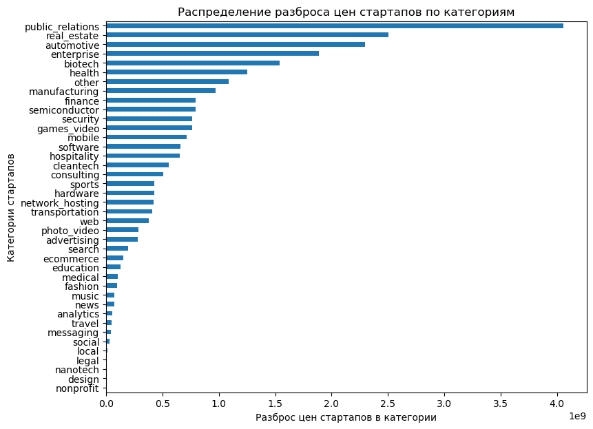

```python
#строим второй график разброса
pv_2.sort_values(by=('std', 'price_amount')).plot(kind='barh', y = ('std', 'price_amount'),
                                                   legend=False, figsize=(9,7),
                                                   ylabel='Категории стартапов',
                                                   xlabel='Разброс цен стартапов в категории',
                                                   title='Распределение разброса цен стартапов по категориям')
plt.show()
```

Теперь можно выделить топ-5 категорий с наибольшим разбросом цен (топ-5, которые больше всего выделяются, далее разница между категориями все меньше):

1. public_relations
2. real_estate
3. automotive
4. enterprise
5. biotech

1. nanotech
2. manufacturing
3. real_estate
4. automotive
5. biotech
6. hospitality

А также получили **топ-5** категорий по разбросу цен (наиболее выделяющиеся):

1. public_relations
2. real_estate
3. automotive
4. enterprise
5. biotech

### Сколько раундов продержится стартап перед покупкой

- Необходимо проанализировать столбец `funding_rounds`. Исследуйте значения столбца. Заказчика интересует типичное значение количества раундов для каждого возможного статуса стартапа.
- Постройте график, который отображает, сколько в среднем раундов финансирования проходило для стартапов из каждой группы. Сделайте выводы.

```python
#отбираем те компании, у которых были раунды финансирования
new_companies_2 = new_companies[new_companies['funding_rounds']>0]
```

```python
#находим типичное количество раундов
new_companies_2.groupby('status')['funding_rounds'].median()
```

```
status
acquired     1.0
closed       1.0
ipo          2.0
operating    1.0
Name: funding_rounds, dtype: float64
```

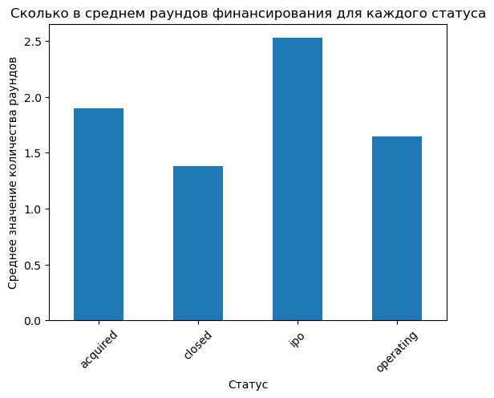

```python
#строим график по среднему количеству раундов
ax = new_companies_2.groupby('status')['funding_rounds'].mean()
ax.plot(kind='bar', xlabel='Статус', ylabel='Среднее значение количества раундов', legend=False, rot=45, title='Сколько в среднем раундов финансирования для каждого статуса')
plt.show()
```

**Выводы**:

- для всех статусов, кроме ipo, медианное значение количества раундов финансирования равно 1. Таким образом, в основном, стартапы проходят один раунд финансирования перед покупкой.
- для статуса "ipo" это значение равно 2, значит для тех, кто вышел на ipo, нужно больше раундов финансирования для покупки
- можем заметить разврыв в значениях между медианой и средним, значит во всех категориях есть стартапы с намного большим количеством раундов, чем медианное

## Итоговый вывод и рекомендации

Опишите, что было сделано в проекте, какие были сделаны выводы, подкрепляют ли они друг друга или заставляют сомневаться в полученных результатах.

**Что было сделано:**

- нами были исследованны 7 датасетов: **acquisition, company_and_rounds, degrees, education, fund, investment, people**
- в датасете **company_and_rounds** названия столбцов привели к snake_case
- типы в столбцах с датами были преобразованы на datetime
- разделили компании по количеству сотрудников на Nano, Micro, Small, Average, More than average, Big
- разделили датасет **company_and_rounds** на два по такому принципу, что в датасете **company** - вся информация о компаниях, а в **rounds** - информация о раундах финансирования
- полученные датасеты предобработали, удалив пропуски и дубликаты
- из датасета **company** выделили строки, в которых `funding_rounds` или `investment_rounds` больше нуля, а в колонке `status` указано acquired. Далее работали с этим датафреймом

**Выводы**:

Таким образом, можно сделать вывод, что нам удалось выделить датасет, по которому можно анализировать компании. Но при этом в данных все еще есть аномальные значения, которые могут исказить показатели, поэтому стоит уделять этому наибольшее значение. Также стоит осторожно использовать данные об образовании сотрудников при построении гипотез, так как размер, например, от этого не зависит.

**Рекомендации:**

- стоит рассмотреть инвестиции в топ-6 категорий (nanotech, manufacturing, real_estate, automotive, biotech, hospitality), отличающихся высокой ценой
- ориентироваться на стартапы, которые прошли небольшое количество раундов финансирования: 1-2. При более поздних стадиях стартапы могут стать менее перспективными и выгодными для покупки
- не концентрироваться на показателях образования сотрудников при принятии решения о покупке
- при совершении сделок в категориях public_relations, real_estate, automotive, enterprise, biotech надо тщательнее изучать компании возможные риски, так как для них характерен довольно большой разброс цен. Но при этом это может принести большую доходность (но при высоком риске)